# Microarray analysis

# Raw data

- Gene expression analysis was made on Illumina HumanHT-12 v4.0 Gene Expression BeadChip
- Raw data were Illumina summary probe profile files in .txt format:
1. Sample Probe Profile
2. Group Probe Profile
3. Control Probe Profile
- Table in .txt with phenotype description for all samples

# Sample Probe Profile

- 16 group samples with 3 replicates for each sample

# Sample Probe Profile

- For each sample: Average signal, Detection p-value, Bead Standard error, Average number of beads
- 34694 genes
- Description columns with Chromosome, Gene symbol, Definition, RefSeq Id, Entrez Id, Protein Id product, Array address Id, Probe start, Sequence, Orientation, Ontology component, process, function, etc.

Average expression between the replicates - Group Sample Probe file.

# The beginning

- I made the slice of the sample probe data to get only sample groups with Gemini, VitD3, TX527 as a treatment and Ethanol as a control (for all samples cell line was THP-1)
- made an ExpressionSet

```
##                   Treatment Replicate
## E.4926.AVG_Signal   Ethanol         1
## E.4927.AVG_Signal   Ethanol         2
## E.4928.AVG_Signal   Ethanol         3
## V.4929.AVG_Signal     VitD3         1
## V.4930.AVG_Signal     VitD3         2
## V.4931.AVG_Signal     VitD3         3
```

# ExpressionSet

```
##         ProbeID SYMBOL
## 6450255 6450255    7A5
## 2570615 2570615   A1BG
## 6370619 6370619   A1BG
## 2600039 2600039   A1CF
## 2650615 2650615   A1CF
## 5340672 5340672   A1CF
##                                                                              DEFINITION
## 6450255                          Homo sapiens putative binding protein 7a5 (7A5), mRNA.
## 2570615                               Homo sapiens alpha-1-B glycoprotein (A1BG), mRNA.
## 6370619                               Homo sapiens alpha-1-B glycoprotein (A1BG), mRNA.
## 2600039 Homo sapiens APOBEC1 complementation factor (A1CF), transcript variant 2, mRNA.
## 2650615 Homo sapiens APOBEC1 complementation factor (A1CF), transcript variant 1, mRNA.
## 5340672 Homo sapiens APOBEC1 complementation factor (A1CF), transcript variant 3, mRNA.
##         ENTREZ_GENE_ID
## 6450255         346389
## 2570615              1
## 6370619              1
## 2600039          29974
## 2650615          29974
## 5340672          29974
```

# ExpressionSet

```
##         E.4926.AVG_Signal E.4927.AVG_Signal E.4928.AVG_Signal
## 6450255          97.48042          96.29398          97.39602
## 2570615         107.31140         110.92790         104.19370
## 6370619         106.56920          96.22334         106.42550
## 2600039          87.52464          77.07726          89.08399
## 2650615          80.00858         102.77970          94.45317
## 5340672          78.35653          73.86353          79.86378
```

# The original distribution

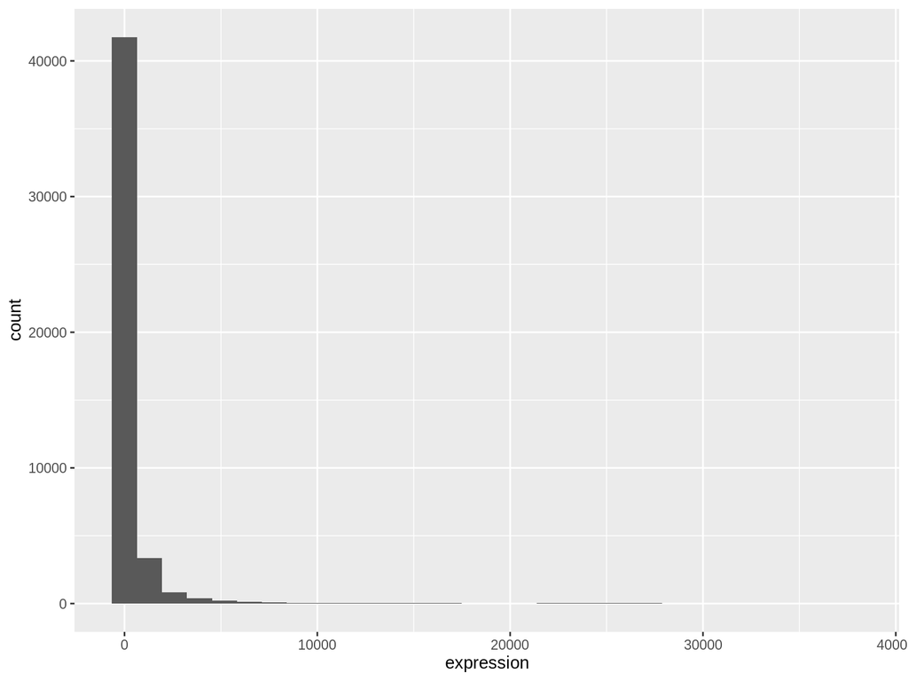

# Log-transformation and quantile normalization

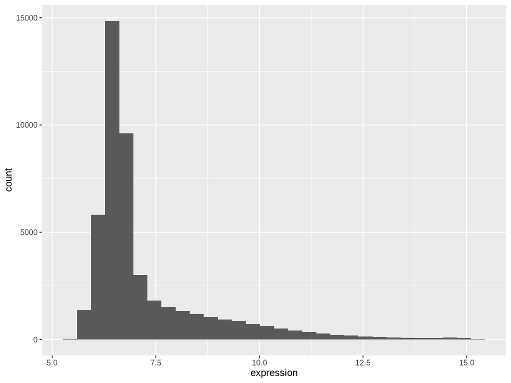

# Mapping probes to genes:

- Removed probes mapped to many genes and no genes
- Calculated average probe expression
- Sorted all probes by average expression
- For each gene kept most-expressed probes
- Left only top 12 000 expressed genes

```
## Features  Samples
##    12000       12
```

# PCA

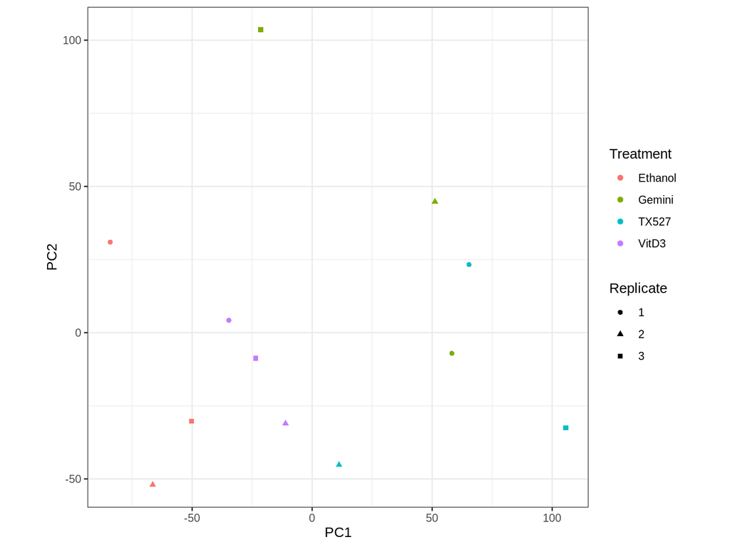

# PCA plot after batch removal

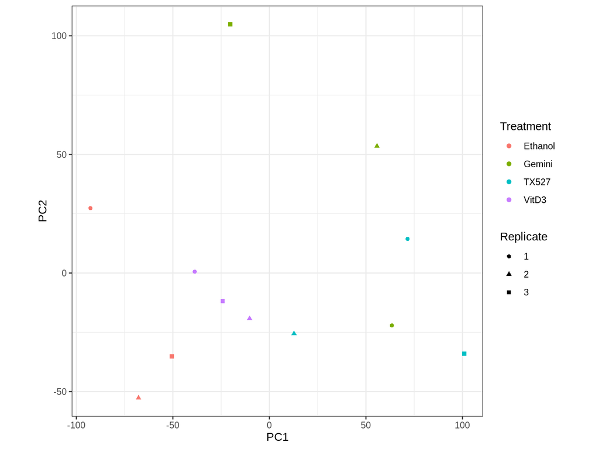

# Differential expression VitaminD3

Volcano Plot

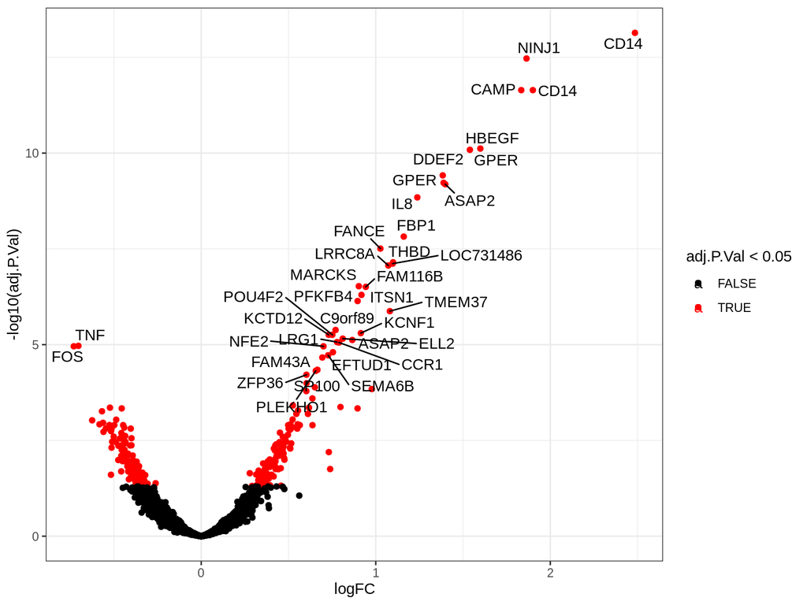

# Differential expression VitaminD3

Table for top KEGG pathways

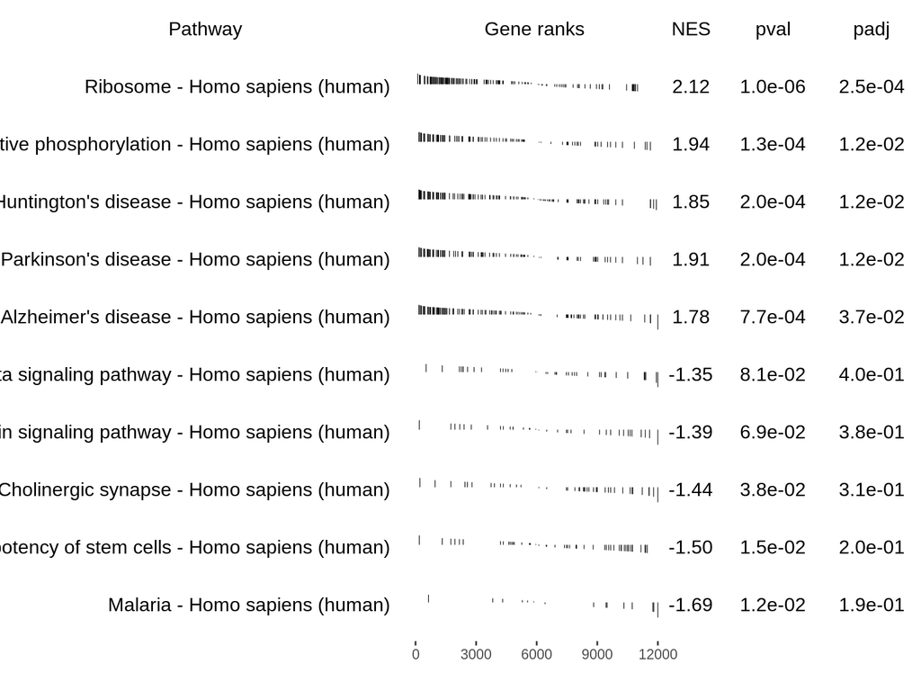

# Differential expression Gemini

Volcano Plot

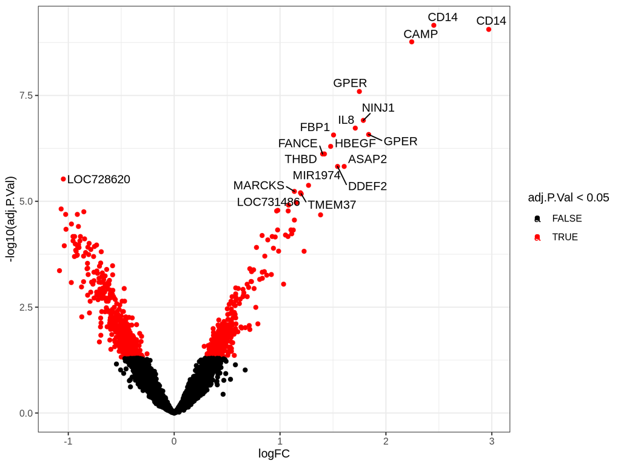

# Differential expression Gemini

Table for top KEGG pathways

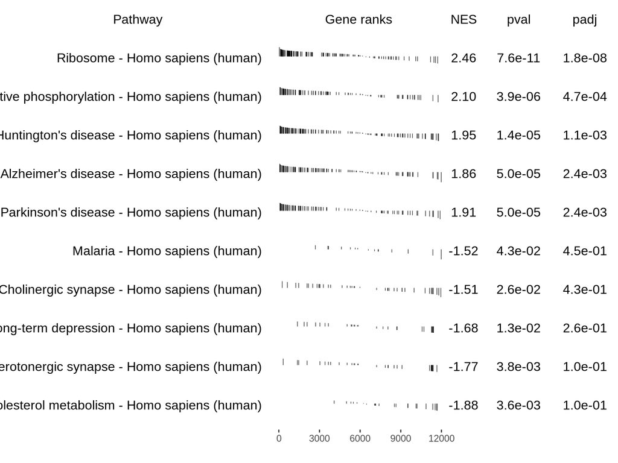

# Differential expression TX527

Volcano Plot

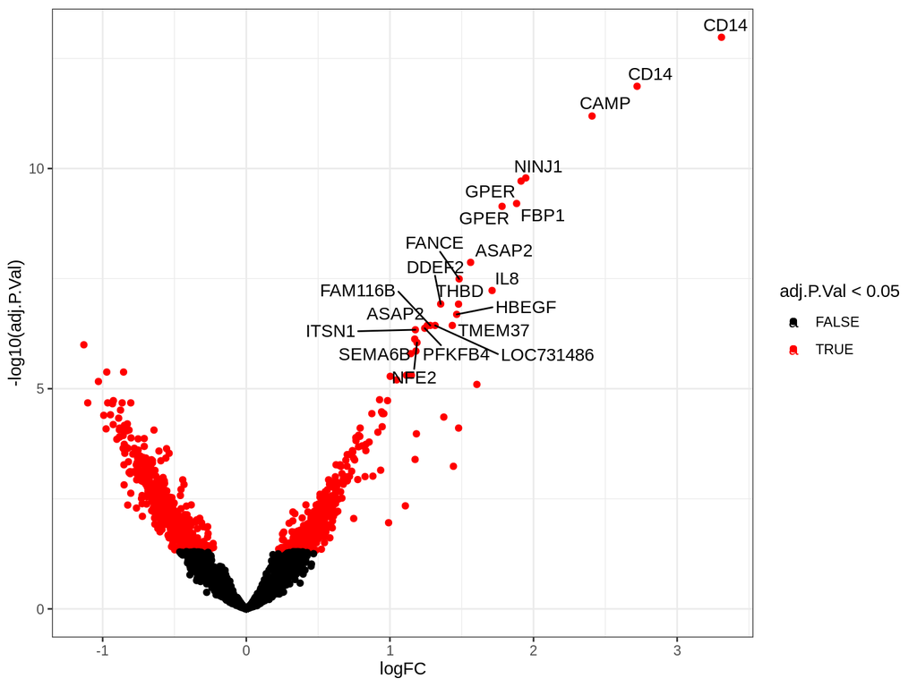

# Differential expression TX527

Table for top KEGG pathways

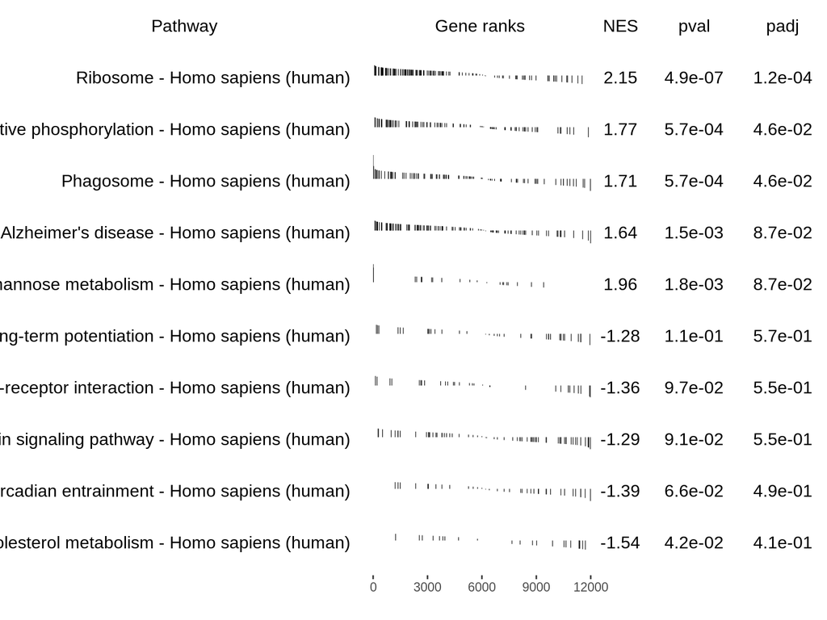